# Pitch Please! Markov Chains in Cal Poly Baseball

Author

Daniel Erro and Rachel Roggenkemper

```r
library(tidyverse)
library(markovchain)
library(MCMCpack)
```

# **Stochastic Processes Applications in Baseball**

Stochastic processes have emerged as a powerful tool in baseball analytics, offering a systematic way to model the inherent randomness of game events. These methods allow analysts to capture the dynamic evolution of game situations—from individual pitch sequences to the broader flow of innings—and to derive insights into both offensive and defensive performance. In particular, Markov chain models have been widely employed to represent game states and the transitions between them, providing a structured approach to predict outcomes such as the next pitch, expected runs, and winning probabilities. In the sections that follow, we first explore the application of Markov chains specifically in pitch sequencing through a review of three articles, to see what has been done already before we delve into our own analyses. We then broaden the discussion to examine how Markov chain models can be applied to other aspects of baseball, such as team performance and strategic decision-making, by reviewing three additional studies (one written by someone at Cal Poly). This layered approach not only illustrates the versatility of stochastic processes in dissecting the game but also sets the stage for our own analysis in this project.

## **Literature in Markov Chains in Pitch Sequencing**

### **Using Markov Chains to Predict Pitches**

https://baseballwithr.wordpress.com/2016/03/31/using-markov-chains-to-predict-pitches/

The article on Baseball with R presents an accessible introduction to applying Markov chain models directly to pitch sequencing. In this study, pitch types are treated as discrete states and the transition probabilities between them are estimated from historical game data. The author emphasizes the predictive power of such a model—by simulating pitch sequences, one can forecast the likely next pitch, a critical component in devising counter‐strategies against opposing batters.

This article was fascinating to see as it reflects very similarly to what we have done with our data. So it was interesting to compare the similarities and differences to our own analysis. A key distinction is the source of the data, where they used data from pitches by Chris Sale and Joe Kelly pitching it the MLB, whereas we used data from Cal Poly baseball.

### **Predicting the Next Pitch: A Markov Chain Approach**

https://www.baseballdatascience.com/predicting-the-next-pitch-a-markov-chain-approach/

This article was an interesting addition to the previous article, as it followed our process of first fitting a Markov chain model using pitch type as our state, and then also incorporating count.

### **Strategic Pitch Location: The Role of Two-Pitch Sequences in Pitching Success**

https://sabr.org/journal/article/strategic-pitch-location-the-role-of-two-pitch-sequences-in-pitching-success/

The SABR Journal article takes a strategic look at pitch sequencing, specifically focusing on two-pitch sequences and their impact on pitch location and subsequent outcomes. It highlights that beyond predicting a single pitch, the model can be extended to capture sequential dependencies that affect a pitcher’s overall success. The work also discusses the potential for linking these sequences to in-game decision-making and situational strategies.

This was an interesting article to see the perspective difference once you switch the state from one pitch to two pitches. We had this idea to expand our state from one pitch to two pitches, but as you’ll see below, we found that in our data, just using one pitch was sufficient for it to count as a Markov chain, so with the advice from Dr. Ross, who said you typically once expand the state if the original one tested was not a Markov chain, we did not expand our state to try and test on with two pitches. However, it was cool to see an example application where they did.

Overall, while all three articles share the common goal of using Markov chain models to predict pitch outcomes, they differ in their emphasis and depth. The Baseball with R article offers a broad overview suitable for an introductory audience, whereas the Baseball Data Science piece delves deeper into the role of contextual variables. The SABR article, meanwhile, extends the model to strategic applications, suggesting that pitch sequencing can inform tactical decisions beyond mere prediction. Together, they illustrate a progression from a basic predictive framework to a sophisticated tool that can influence game strategy.

## **Broader Applications of Markov Chains in Baseball**

In the realm of Markov chains in baseball, beyond the applications in pitch sequencing in particular, there are plenty of other applications. While our project focuses on pitch sequencing specifically, we also wanted to explore other applications of application of markov chains in baseball in general. So below, we briefly summarize three papers that discuss applications of markov chains in baseball besides from pitch sequencing.

### **Markov League Baseball: Baseball Analysis Using Markov Chains**

https://digitalcommons.calpoly.edu/cgi/viewcontent.cgi?article=1063&context=statsp

This article was cool because it was actually publsihed from a student in the Cal Poly Statistics Department back in 2016. This article applies Markov chain methods to analyze overall team performance. It goes beyond individual pitch sequencing by modeling transitions between different game states (such as base-runner configurations and outs) to estimate expected runs. The study offers insights into how teams can evaluate offensive efficiency and make data-driven decisions regarding lineup construction and player value.

### **Markov Chain Theory with Applications to Baseball**

https://openworks.wooster.edu/cgi/viewcontent.cgi?referer=&httpsredir=1&article=6727&context=independentstudy

Presented as a senior independent study, this work lays out the theoretical foundations of Markov chains and then applies these principles to baseball. It explains key concepts such as absorbing states and the fundamental matrix, then demonstrates how these ideas can be used to compute expected runs and win probabilities. The approach is more mathematically rigorous, aiming to bridge the gap between theory and practical analysis.

### **An Additional Perspective on Markov Models in Baseball**

https://web.njit.edu/~bukiet/Papers/ball.pdf

This article offers yet another view on applying Markov models within baseball. Although its focus is not on pitch sequencing, it complements the previous studies by addressing other facets of the game—such as the dynamics of batting and fielding outcomes. This work highlights the flexibility of Markov chain models in capturing the evolution of game situations and further supports the notion that such stochastic processes can be powerful tools in evaluating both offensive and defensive performance.

The three articles discussed above collectively demonstrate how Markov chain models can be extended to various aspects of baseball beyond pitch sequencing. The articles emphasize team-level analysis and the mathematical underpinnings of expected run computations. Together, they form a comprehensive overview of how stochastic processes can be used to dissect and predict game outcomes across multiple dimensions.

In summary, the literature on the application of Markov chains in baseball that we rewsearched can be broadly divided into two groups. The first groups focuses on pitch sequencing, where the state–transition models are used to predict the next pitch and assess strategic variations in a pitcher’s approach. The articles illustrate an evolution from introductory models to sophisticated analyses that incorporate situational data and sequential dependencies. The second group extends these models to the broader game, encompassing aspects such as offensive production, defensive performance, and simulation-based strategy optimization. By comparing and contrasting these studies, especially comparing the pitching sequencing articles to what we performed, we see that while the methodologies and emphases may vary, all these applications underscore the power and flexibility of Markov chain models in transforming raw baseball data into predictive and strategic insights.

```r
df1 <- read.csv(here::here("data", "2-16-24_CalPoly_Missouri_G1.csv"))
df2 <- read.csv(here::here("data", "2-23-24_CalPoly_Texas.csv"))
df3 <- read.csv(here::here("data", "3-2-24_CalPoly_Utah.csv"))
df4 <- read.csv(here::here("data", "3-8-24_CalPoly_OhioState.csv"))
df5 <- read.csv(here::here("data", "3-15-24_CalPoly_CSUN.csv"))
df6 <- read.csv(here::here("data", "3-22-24_CalPoly_UCSB.csv"))
df7 <- read.csv(here::here("data", "4-12-24_CalPoly_Bakersfield_G1.csv"))
df8 <- read.csv(here::here("data", "4-26-24_CalPoly_UCDavis.csv"))
df9 <- read.csv(here::here("data", "5-10-24_CalPoly_UtahTech.csv"))
df10 <- read.csv(here::here("data", "5-23-24_CalPoly_LongBeachState.csv"))

df_full <- rbind(df1, df2, df3, df4, df5, df6, df7, df8, df9, df10)

df_wright <- df_full %>%
  filter(Pitcher == "Wright, Jakob") %>%
  mutate(ObsNo = row_number()) %>%
  dplyr::select(ObsNo, Date, PitchofPA, Pitcher, Batter, BatterSide, Inning, Outs, Balls, Strikes, TaggedPitchType, PitchCall, KorBB, TaggedHitType:RunsScored, RelSpeed:PlateLocSide, VertApprAngle, HorzApprAngle)
```

```r
df_clean <- df_wright %>%
  mutate(PitchType = case_when(
    (InducedVertBreak > 11.73 | RelSpeed > 94) & HorzBreak < 2 & SpinRate > 2100 ~ "Fastball",
    HorzBreak < 2 & SpinRate > 2100 ~ "Fastball",
    SpinRate < 2100 & HorzBreak < 0 ~ "Changeup",
    HorzBreak > 13.95 & RelSpeed < 84 & SpinRate > 2100 ~ "Slider",
    HorzBreak > 17 ~ "Slider",
    TRUE ~ "Cutter"
  )) %>%
  mutate(PitchCall = recode(PitchCall, "FoulBallNotFieldable" = "FoulBall")) %>%
  mutate(Opponent = case_when(
    ObsNo == 365 | Date == "2024-03-08" ~ "Ohio State",
    Date == "" | Date == "2024-03-02" ~ "Utah",
    Date == "2024-02-16" ~ "Missouri",
    Date == "2024-02-23" ~ "Texas",
    Date == "2024-03-15" ~ "CSUN",
    Date == "2024-03-22" ~ "UC Santa Barbara",
    Date == "2024-04-12" ~ "Bakersfield",
    Date == "2024-04-26" ~ "UC Davis",
    Date == "2024-05-10" ~ "Utah Tech",
    Date == "2024-05-23" ~ "Long Beach State",
    TRUE ~ "ballz"
  )) %>%
  dplyr::select(ObsNo, Opponent, Pitcher, Batter, BatterSide, PitchType, InducedVertBreak, HorzBreak, Inning, PitchofPA, Outs, Balls, Strikes, PitchCall) %>%
  drop_na() %>%
  mutate(prevPitchType = lag(PitchType)) %>%
  mutate(PitchWOuts = paste(PitchType, Outs, sep = ", ")) %>%
  mutate(PitchWCount = paste(PitchType, Balls, Strikes, sep = ", "))
```

```r
df_clean %>%
  group_by(PitchType) %>%
  summarise(Count = n()) %>%
  mutate(Proportion = (Count / sum(Count))) %>%
  arrange(desc(Proportion))
```

# Description of Data

The data used in this project was collected at home games by the Cal Poly baseball analytics team during the 2024 Cal Poly baseball season. Each observation represents a pitch, and the pitches are sequenced chronologically. Over the course of each game, metrics on each pitch are recorded by the Trackman radar system. These metrics include the spin rate of the baseball (RPM), the vertical and horizontal movement (in), and the velocity (MPH). Trackman also keeps track of game data such as the outs, count, and inning, as well as information about the batter and pitcher, such as their handedness.

Using the pitch metric data, we are able to identify the pitch types. These metrics can be particular to each pitcher, but since we were using data only from left-handed pitcher Jakob Wright, it was simple to separate his pitch types. For example, Jakob’s Fastball ranges from about 91-95 MPH, and it has negative horizontal break (arm side run). The only other pitch in his arsenal with arm side run is his Changeup, but his Changeup has a very low spin rate, so Fastballs and Changeups are easy to separate from the other pitch types. The Slider and Cutter are similar, but Cutters tend to have higher velocities and less positive horizontal break than the Sliders.

Our final cleaned dataset (df_clean) included variables such as the PitchType (Fastball, Slider, etc.), Outs, Balls, and Strikes.

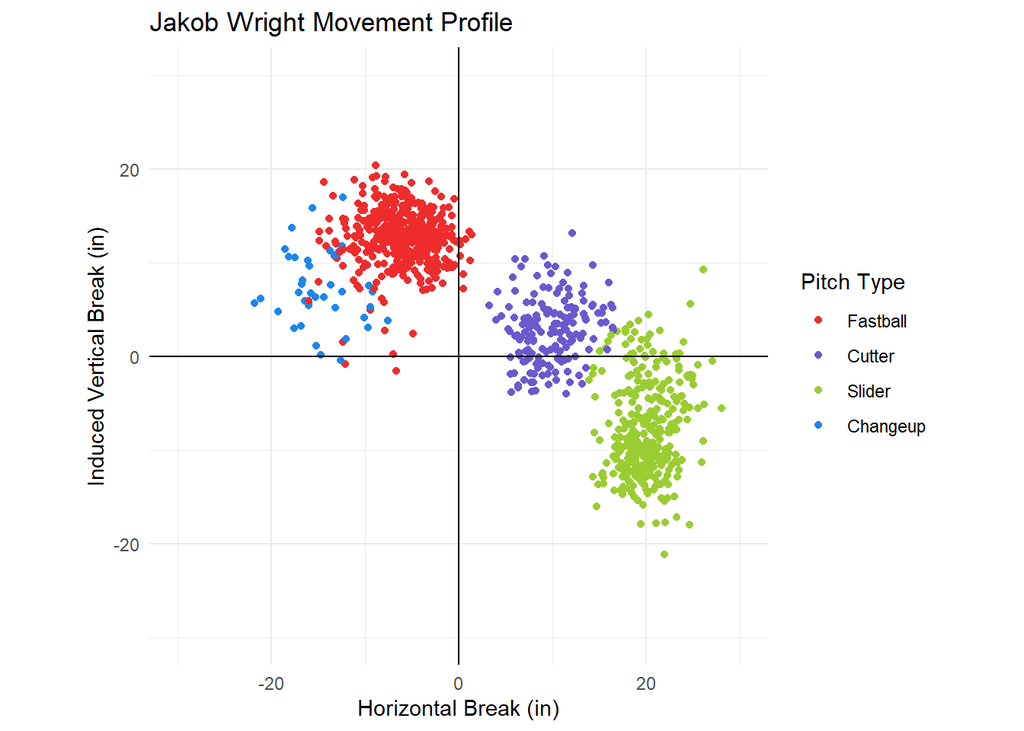

```r
manual_colors <- c("firebrick2", "slateblue", "olivedrab3", "dodgerblue2")
group_order <- c("Fastball", "Cutter", "Slider", "Changeup")

ggplot(df_clean, aes(x = HorzBreak, y = InducedVertBreak, color = PitchType)) +
      geom_point(stat = "identity") +
      scale_color_manual(values = manual_colors,
                         limits = group_order,
                         labels = c("Fastball", "Cutter", "Slider", "Changeup")) +
      ggtitle(glue::glue("Jakob Wright Movement Profile")) +
      xlab("Horizontal Break (in)") +
      ylab("Induced Vertical Break (in)") +
      guides(color = guide_legend(title = "Pitch Type")) +
      xlim(-30, 30) +
      ylim(-30, 30) +
      geom_vline(xintercept=0) +
      geom_hline(yintercept=0) +
      theme_minimal() +
      coord_fixed()
```

# Markov Chains and Pitch Sequencing

In order to proceed with our project, we first needed to find out what we needed to define as states for our Markov chain. The first thing we tried was defining only the pitch type as each state. We were able to verify that the pitch types as states did in fact follow a Markov chain, but we wanted to add a little more information into our states. We added outs to the state, which we also verified to follow a Markov chain. Finally, we decided to add the count to the state (without the outs), and pitch type with count also followed a Markov chain. So, we decided to define each state as the pitch type with the count (e.g. “Slider, 0-0”, “Fastball, 3-2”, etc.).

```r
transition_matrix <- df_clean %>%
  mutate(next_pitch = lead(PitchType)) %>%  # Create a column for the next pitch in the sequence
  filter(!is.na(next_pitch)) %>%  # Remove the last row with NA (since there is no next pitch)
  group_by(PitchType, next_pitch) %>%  # Group by the current pitch and the next pitch
  summarise(Count = n(), .groups = 'drop')

transition_matrix_wide <- transition_matrix %>%
  spread(key = next_pitch, value = Count, fill = 0)

transition_matrix_props <- transition_matrix_wide %>%
  mutate(across(2:5,
                ~ if_else(PitchType == "Changeup", ., .))) %>%
  mutate(across(2:5,
                ~ if_else(PitchType == "Cutter", ., .))) %>%
  mutate(across(2:5,
                ~ if_else(PitchType == "Fastball", ., .))) %>%
  mutate(across(2:5,
                ~ if_else(PitchType == "Slider", ., .)))

transition_matrix_props <- transition_matrix_props[c(3, 4, 2, 1), ] %>%
  dplyr::select(PitchType, Fastball, Slider, Cutter, Changeup)

transition_matrix_props[, -1]
```

```r
pitch_list <- df_clean$PitchType

mc_fit = markovchainFit(data = pitch_list, method = "mle")
```

```r
createSequenceMatrix(pitch_list)
```

```r
P <- mc_fit$estimate@transitionMatrix

pi_0 <- c(0.03925417, 0.19430815, 0.43866536, 0.32777233)
```

```r
simulate_single_DTMC_path <- function(initial_distribution, transition_matrix, last_time){

  n_states = nrow(transition_matrix) # number of states

  states = 1:n_states # state space

  X = rep(NA, last_time + 1) # state at time n; +1 to include time 0

  X[1] = sample(states, 1, replace = TRUE, prob = initial_distribution) # initial state

  for (n in 2:(last_time + 1)){

    X[n] = sample(states, 1, replace = TRUE, prob = transition_matrix[X[n-1], ])

  }

  return(X)

}
```

```r
set.seed(36)

x_current = factor(simulate_single_DTMC_path(pi_0, P, 50000))
```

```r
verifyMarkovProperty(x_current)
```

```
Testing markovianity property on given data sequence
Chi - square statistic is: 20.92457
Degrees of freedom are: 50
And corresponding p-value is: 0.9999059
```

# Pitch Type and Outs

```r
pi_0_pitch_outs <- df_clean %>%
  group_by(PitchWOuts) %>%
  summarise(Count = n()) %>%
  mutate(Proportion = (Count / sum(Count))) %>%
  arrange(desc(Proportion))
```

```r
pitch_outs_list <- df_clean$PitchWOuts

mc_fit = markovchainFit(data = pitch_outs_list, method = "mle")
```

```r
createSequenceMatrix(pitch_outs_list)
```

```r
P2 <- mc_fit$estimate@transitionMatrix

pi_02 <- pi_0_pitch_outs$Proportion
```

```r
set.seed(36)

x_current2 = factor(simulate_single_DTMC_path(pi_02, P2, 50000))
```

```r
verifyMarkovProperty(x_current2)
```

```
Testing markovianity property on given data sequence
Chi - square statistic is: 414.6476
Degrees of freedom are: 486
And corresponding p-value is: 0.9915682
```

## Pitch Type and Count

```r
pi_0_pitch_count <- df_clean %>%
  group_by(PitchWCount) %>%
  summarise(Count = n()) %>%
  mutate(Proportion = (Count / sum(Count))) %>%
  arrange(desc(Proportion))

slider30 <- c("Slider, 3, 0", 0, 0)
changeup20 <- c("Changeup, 2, 0", 0, 0)
changeup21 <- c("Changeup, 2, 1", 0, 0)
changeup30 <- c("Changeup, 3, 0", 0, 0)
changeup32 <- c("Changeup, 3, 2", 0, 0)
cutter30 <- c("Cutter, 3, 0", 0, 0)
cutter31 <- c("Cutter, 3, 1", 0, 0)


pi_0_pitch_count <- rbind(pi_0_pitch_count, slider30, changeup20, changeup21, changeup30, changeup32, cutter30, cutter31)
```

```r
pitch_count_list <- df_clean$PitchWCount

mc_fit = markovchainFit(data = pitch_count_list, method = "mle")
```

```r
createSequenceMatrix(pitch_count_list)
```

```r
P3 <- mc_fit$estimate@transitionMatrix

P3 <- as.data.frame(P3)

# Add new columns
P3 <- P3 %>%
  mutate(`Slider, 3, 0` = 0) %>%
  mutate(`Changeup, 2, 0` = 0) %>%
  mutate(`Changeup, 2, 1` = 0) %>%
  mutate(`Changeup, 3, 0` = 0) %>%
  mutate(`Changeup, 3, 2` = 0) %>%
  mutate(`Cutter, 3, 0` = 0) %>%
  mutate(`Cutter, 3, 1` = 0)

# Add new rows
new_row <- rep(0, ncol(P3))
P3 <- rbind(P3, new_row, new_row, new_row, new_row, new_row, new_row, new_row)

# Rename just the last 7 rows
rownames(P3)[(nrow(P3) - 6):nrow(P3)] <- c("Slider, 3, 0", "Changeup, 2, 0", "Changeup, 2, 1", "Changeup, 3, 0", "Changeup, 3, 2", "Cutter, 3, 0", "Cutter, 3, 1")

P3 <- as.matrix(P3)

pi_03 <- pi_0_pitch_count$Proportion
```

```r
set.seed(36)

x_current3 = factor(simulate_single_DTMC_path(pi_03, P3, 50000))
```

```r
verifyMarkovProperty(x_current3)
```

```
Testing markovianity property on given data sequence
Chi - square statistic is: 1453.095
Degrees of freedom are: 1656
And corresponding p-value is: 0.9998784
```

## LHH vs RHH

In the future, we might want to split up our dataset by right-handed hitters and left-handed hitters, because most pitchers will likely mix up their pitch sequencing based on what handedness the batter is. For example, against right-handed hitters, Jakob Wright primarily relies on his Fastball, Cutter, and Changeup to get hitters out. However, against left-handed hitters, Wright typically uses is Fastball, Slider, then Cutter to get hitters out. This is typical behavior among pitchers, since it is usually seen as advantageous to the pitcher to have your pitches “run away” from the hitter. So, Wright rarely throws his Changeup to lefties, since those pitches move toward the barrel of the bat of a left-handed hitter, but away from the bat of a right-handed hitter.

## Continuous Time Markov Chains Applications in Baseball

While we focused on applying DTMC to pitch sequencing, we acknowledge that there is a whole realm of application using continuous time Markov chains (CTMCs). CTMCs offer a framework that explicitly incorporates the time between events. In a CTMC, not only are the transitions between game states modeled, but each state is also associated with a waiting time—typically assumed to follow an exponential distribution. This approach would allow us to capture the dynamics of a baseball game, providing insight into both the pace of play and the overall game duration.

One potential application of CTMCs in baseball is the simulation of game length. By estimating the distribution of time intervals between successive pitches, we can model how long an inning—or an entire game—is likely to last. For instance, when a batter is put out, additional time may be required before the next batter takes the plate due to pitcher resetting, field adjustments, or a brief pause in play. Similarly, the time between innings is characteristically longer than the time between individual pitches. In a CTMC framework, these different waiting times can be incorporated as state-dependent transition rates. For example, one might assign a slower rate for transitions following an out compared to transitions following a hit, and model the inter-inning break as a transition into a unique “in-between innings” state with its own holding time.

Although we did not implement a CTMC in our current project, these ideas suggest a direction for future research, offering a more granular perspective on the flow of a baseball game.

In summary, continuous-time Markov chain models extend the traditional discrete framework by embedding time into the state transitions. This approach provides a means to analyze the variability in game duration, to study the effects of events that slow down or speed up play, and ultimately to better understand the structure of baseball. Such models could complement existing analyses by highlighting how modifications in the pace of play—whether due to in-game events or external factors—affect overall performance and strategy.

# Markov Chain Monte Carlo

Our MCMC algorithm is designed to simulate a sequence of pitch types based on a precomputed Markov transition matrix using a simplified Metropolis–Hastings framework. The function begins with an initial pitch (by default “Fastball”) and then iterates for a specified number of steps. At each iteration, it retrieves the row of the transition matrix corresponding to the current pitch, which represents the conditional probabilities for all possible next pitches given the current state.

Since the proposal distribution in our algorithm is exactly the transition probabilities provided by the matrix, the typical Metropolis–Hastings acceptance step simplifies considerably—in effect, every proposed pitch is accepted. In other words, our algorithm directly samples the next pitch from the current state’s probability distribution. By repeating this process over many steps, the function generates a long simulated pitch sequence that reflects the stochastic dynamics encoded in the transition matrix. This simulation can then be used to analyze pitch sequencing patterns and assess strategic variations over the course of a game.

```r
transition_matrix <- P

pitch_types <- c("Changeup", "Cutter", "Fastball", "Slider")
rownames(transition_matrix) <- pitch_types
colnames(transition_matrix) <- pitch_types

# Simulation
simulate_pitches_mcmc <- function(n, transition_matrix, start_pitch = "Fastball") {
  states <- rownames(transition_matrix)
  pitch_seq <- character(n)
  pitch_seq[1] <- start_pitch  # Start with given pitch

  for (i in 2:n) {
    current_pitch <- pitch_seq[i - 1]
    probs <- transition_matrix[current_pitch, ]
    pitch_seq[i] <- sample(states, size = 1, prob = probs)
  }

  return(pitch_seq)
}

# Run MCMC to generate 100 pitch sequences
set.seed(42)
pitch_sequence <- simulate_pitches_mcmc(n = 100, transition_matrix)

# Print first 20 pitches
print(pitch_sequence[1:20])
```

```
 [1] "Fastball" "Cutter"   "Cutter"   "Fastball" "Cutter"   "Slider"
 [7] "Slider"   "Slider"   "Fastball" "Slider"   "Slider"   "Slider"
[13] "Slider"   "Cutter"   "Fastball" "Fastball" "Cutter"   "Cutter"
[19] "Fastball" "Fastball"
```

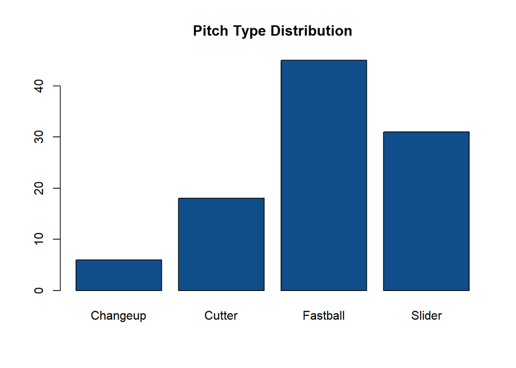

```r
# Plot frequency of pitches in the sequence
barplot(table(pitch_sequence), main = "Pitch Type Distribution", col = "dodgerblue4")
```

```r
transition_matrix <- P3

pitch_types <- colnames(P3)
rownames(transition_matrix) <- pitch_types
colnames(transition_matrix) <- pitch_types

# Simulation
simulate_pitches_mcmc <- function(n, transition_matrix, start_pitch = "Fastball, 0, 0") {
  states <- rownames(transition_matrix)
  pitch_seq <- character(n)
  pitch_seq[1] <- start_pitch  # Start with given pitch

  for (i in 2:n) {
    current_pitch <- pitch_seq[i - 1]
    probs <- transition_matrix[current_pitch, ]
    pitch_seq[i] <- sample(states, size = 1, prob = probs)
  }

  return(pitch_seq)
}

# Run MCMC to generate 100 pitch sequences
set.seed(42)
pitch_sequence <- simulate_pitches_mcmc(n = 100, transition_matrix)

# Print first 20 pitches
print(pitch_sequence[1:40])
```

```
 [1] "Fastball, 0, 0" "Cutter, 1, 0"   "Cutter, 0, 0"   "Cutter, 1, 0"
 [5] "Slider, 0, 0"   "Slider, 1, 0"   "Fastball, 2, 0" "Cutter, 2, 1"
 [9] "Fastball, 3, 1" "Slider, 0, 0"   "Slider, 1, 0"   "Fastball, 2, 0"
[13] "Cutter, 2, 1"   "Cutter, 2, 2"   "Fastball, 0, 0" "Fastball, 1, 0"
[17] "Changeup, 1, 1" "Slider, 1, 2"   "Fastball, 0, 0" "Fastball, 1, 0"
[21] "Cutter, 1, 1"   "Fastball, 0, 0" "Fastball, 0, 1" "Changeup, 1, 1"
[25] "Slider, 1, 2"   "Fastball, 0, 0" "Slider, 0, 1"   "Slider, 0, 2"
[29] "Fastball, 0, 2" "Slider, 1, 2"   "Slider, 0, 0"   "Cutter, 0, 1"
[33] "Fastball, 1, 1" "Cutter, 2, 1"   "Slider, 2, 2"   "Fastball, 0, 0"
[37] "Fastball, 0, 0" "Fastball, 0, 1" "Slider, 0, 2"   "Fastball, 0, 2"
```

```r
# Plot frequency of pitches in the sequence
# barplot(table(pitch_sequence), main = "Pitch Type Distribution", col = "dodgerblue4")

df_sequence <- as.data.frame(table(pitch_sequence))

df_sequence <- df_sequence %>%
  mutate(pitch_sequence = str_replace(pitch_sequence, "([^,]+),\\s*(\\d+),\\s*(\\d+)", "\\1 (\\2-\\3)"))
```

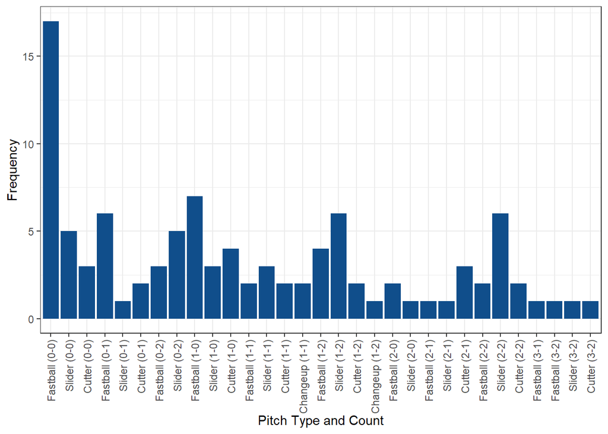

```r
colnames(df_sequence) <- c("PitchSequence", "Freq")

# Extract pitch count and pitch type
df_sequence <- df_sequence %>%
  mutate(PitchCount = str_extract(PitchSequence, "\\(\\d+-\\d+\\)"),  # Extract count (e.g., "(0-0)")
         PitchType = str_extract(PitchSequence, "^[A-Za-z]+"),  # Extract pitch type
         PitchCount = factor(PitchCount, levels = unique(sort(PitchCount))),  # Order by count
         PitchType = factor(PitchType, levels = c("Fastball", "Slider", "Cutter", "Changeup"))) %>%  # Order pitch types
  arrange(PitchCount, PitchType)  # Sort first by count, then by pitch type

# Update ggplot with new ordering
ggplot(df_sequence, aes(x = factor(PitchSequence, levels = df_sequence$PitchSequence), y = Freq)) +
  geom_col(fill = "dodgerblue4") +
  labs(x = "Pitch Type and Count", y = "Frequency") +
  theme_bw() +
  theme(axis.text.x = element_text(angle = 90, vjust = 0.5, hjust = 1))
```

# How our Project can be applied

**1. Simulated Distribution of Pitches**

Our project can be used by the Cal Poly baseball team in a few different ways. One way the team could use our algorithm is by examining the simulated distribution of pitch types and sequences of opposing pitchers using our Metropolis-Hastings algorithm. For example, if we have a big series against UC Santa Barbara coming up, we can filter data from previous games for specific pitchers on the UCSB roster to get an idea of how they are sequencing their pitches. This will allow our coaches and hitters to get a general idea of the pitchers’ typical strategies, and our hitting coaches can come up with a plan of attack.

**2. Predicting Next Pitch Type**

Another way our algorithm can be used by the baseball team is to predict the next pitch type based on the known previous pitch type. We would be able to do this one pitch at a time by setting the start_pitch to what the previous pitch was, e.g. “Fastball, 0, 0” would represent an 0-0 Fastball. Then we can set our algorithm to simulate two pitches, and the second pitch in the sequence would represent the simulated next pitch type.

**3. Simulate a Game**

A third way our algorithm could be used is to simulate an entire baseball game. We would need to add at-bat results to the simulation to truly represent the outcomes of a baseball game, but our algorithm currently simulates at-bats from start to finish, with the count resetting after an at-bat ends. With this framework already in place, it would not be difficult to simulate a game that included information on each pitch type, the count, and the result of the at-bat. You would then be able to calculate simulated strike percentage, hits given up, earned runs, and much more.

# Further Applications: Poisson Process and Hidden Markov Models

In addition to Markov chain analysis, two other stochastic process frameworks present promising avenues for further exploration in baseball analytics: the Poisson process and the Hidden Markov Model (HMM).

While our project doesn’t include a Poisson process implmentation, a Poisson process is particularly well-suited for modeling rare or discrete events, such as strikeouts and walks, over the course of a game. By assuming that these events occur at a certain average rate—either constant or varying with game conditions (as in a non-homogeneous Poisson process)—one can analytically derive the probability of a given number of strikeouts or walks within a specified time interval. Such an approach provides a powerful analytical tool that complements simulation methods, allowing us to evaluate whether factors such as fatigue or strategic adjustments might change event rates as the game progresses.

The Hidden Markov Model, on the other hand, offers a way to account for latent factors influencing pitch selection. While our project does not include an implementation of HMMs, the theoretical appeal is clear: an HMM assumes that observed sequences (in our case, the types of pitches thrown) are generated by an underlying process with hidden states. These latent states could represent a pitcher’s strategic mindset or adjustments made in response to the batter’s performance. By inferring these hidden states from the observable pitch sequences, one could gain deeper insights into how pitchers switch between aggressive, deceptive, or conservative modes.

Together, these two modeling approaches highlight the interplay between theory and application in baseball analytics. Although our project focuses primarily on a Markov chain framework and simulation-based methods, discussing the potential of Poisson processes and Hidden Markov Models underscores how diverse stochastic process tools can be applied to the challenges of sports analysis. As such, these ideas provide a foundation for future research that could further bridge the gap between theoretical models and real-world baseball performance.